# Astrazeneca completed test

# Le Model and his parameters

```python
# Let's create an objet Linear regression
model = LinearRegression()

# fit our model
model.fit(x_train,y_train)
```

```
LinearRegression(copy_X=True, fit_intercept=True, n_jobs=None, normalize=False)
```

```python
# Score or our model cost
print("Score R2 =", model.score(x_train,y_train))
print("Interception =", model.intercept_)
print("Coefficent =", model.coef_)
```

```
Score R2 = 1.0
Interception = -18062.999999999993
Coefficent = [9.]
```

### !!! Our modèle is not so good, it's must be cause of the lack of data and the outlier values. However we can predict

### Training set

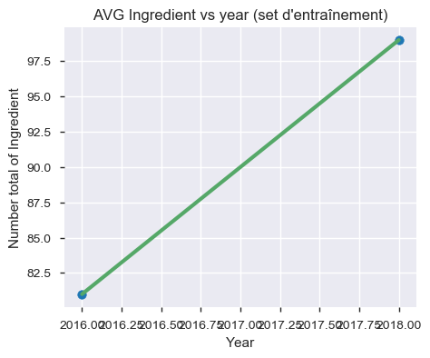

```python
plt.rcParams["figure.figsize"] = [5,4]
# Evaluons notre modèle
plt.scatter(x_train,y_train)

# Y prédit (Predire le résultat de l'ensemble des tests pour ce modèle)
y_pred = model.predict(x_train)

# Traçons notre modèle
plt.plot(x_train, y_pred, c = 'g', lw = 3)

# Labels et titres
plt.title('AVG Ingredient vs year (set d\'entraînement)')
plt.xlabel('Year')
plt.ylabel('Number total of Ingredient')
plt.show()
```

### Testing Set

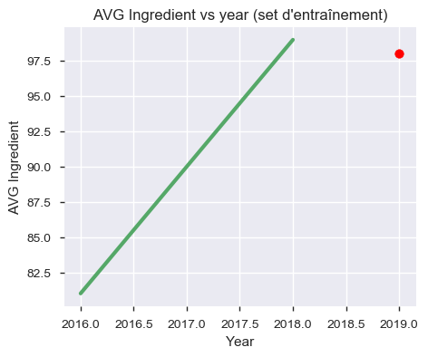

```python
plt.rcParams["figure.figsize"] = [5,4]
# maintenant regardons notre modèle dans le set de test
# Evaluons notre modèle
plt.scatter(x_test,y_test, color = 'red')

# Y prédit
y_pred = model.predict(x_train)

# Traçons notre modèle
plt.plot(x_train, y_pred, c = 'g', lw =3)

# Labels et titres
plt.title('AVG Ingredient vs year (set d\'entraînement)')
plt.xlabel('Year')
plt.ylabel('AVG Ingredient')
plt.show()
```

### Let's try to predict Number_of_ingredients per year

- y (total) value depends on de x (year) and Route ( i didn't include it for this test )

```python
# Try to predict total_ingredient in year 2020
year = [[2020]]
year_int = str(year).replace("[","").replace("]","").replace("","")

# Prédiction de prix
total = model.predict(year)
print('The total number of ingredients in year {} will be {}'.format(year_int,int(total)))
```

```
The total number of ingredients in year 2020 will be 117
```

# Conclusion ( predict the total number of ingredient next year )

in 2020 we will have as total number of ingredient: 117 arrording. If we add route we will use Mutlti linear regression cause our avg is going to depend on two variables route and year. We also have Logistique regression by exemple. The best way is to test each model to see the good one to fit we our target.

## Question 2

Could you find the most common drug interactions for AstraZeneca medicines?

#### Answer 2

Yeah we can with data mining and ML Technique!

## Question 3

How would you deploy your analysis/model as a tool that other users can use?

How would you deploy your analysis/model as a tool that other users can use

#### Answer 3

I will deploy my analysis via an API that do the same work that Open FDA, or another way web site application. we can also use R Shiny with everything done, Django etc....

# !My first approach to the test : Download all the dataset directly on the page

```python
''''
# Import library
#---------------
import requests
#import json
#import pandas as pd


# get the list name of all the data
#----------------------------------
list = []
for value in range(1,9):
    list.append('https://download.open.fda.gov/drug/label/drug-label-000'+str(value)+'-of-0008.json.zip')
print(list)

# Downoad data on the internet
# -----------------------------
wget.download(list[0],r'C:\Users\Hurgland-Nick KELIET\Desktop\Astra zeneca data scientist test\drug-label-0001-of-0008.zip')
wget.download(list[1],r'C:\Users\Hurgland-Nick KELIET\Desktop\Astra zeneca data scientist test\drug-label-0002-of-0008.zip')
wget.download(list[2],r'C:\Users\Hurgland-Nick KELIET\Desktop\Astra zeneca data scientist test\drug-label-0003-of-0008.zip')
wget.download(list[3],r'C:\Users\Hurgland-Nick KELIET\Desktop\Astra zeneca data scientist test\drug-label-0004-of-0008.zip')
wget.download(list[4],r'C:\Users\Hurgland-Nick KELIET\Desktop\Astra zeneca data scientist test\drug-label-0005-of-0008.zip')
wget.download(list[5],r'C:\Users\Hurgland-Nick KELIET\Desktop\Astra zeneca data scientist test\drug-label-0006-of-0008.zip')
wget.download(list[6],r'C:\Users\Hurgland-Nick KELIET\Desktop\Astra zeneca data scientist test\drug-label-0007-of-0008.zip')
wget.download(list[7],r'C:\Users\Hurgland-Nick KELIET\Desktop\Astra zeneca data scientist test\drug-label-0008-of-0008.zip')


# Load all of the data downloaded
#--------------------------------
lb_drug_1 = json.load(open('C:/Users/Hurgland-Nick KELIET/Desktop/Astra zeneca data scientist test/drug-label-0001-of-0008.json'))
lb_drug_1 = pd.DataFrame(lb_drug_1['results'])

lb_drug_2 = json.load(open('C:/Users/Hurgland-Nick KELIET/Desktop/Astra zeneca data scientist test/drug-label-0002-of-0008.json'))
lb_drug_2 = pd.DataFrame(lb_drug_2['results'])

lb_drug_3 = json.load(open('C:/Users/Hurgland-Nick KELIET/Desktop/Astra zeneca data scientist test/drug-label-0003-of-0008.json'))
lb_drug_3 = pd.DataFrame(lb_drug_3['results'])

lb_drug_4 = json.load(open('C:/Users/Hurgland-Nick KELIET/Desktop/Astra zeneca data scientist test/drug-label-0004-of-0008.json'))
lb_drug_4 = pd.DataFrame(lb_drug_4['results'])

lb_drug_5 = json.load(open('C:/Users/Hurgland-Nick KELIET/Desktop/Astra zeneca data scientist test/drug-label-0005-of-0008.json'))
lb_drug_5 = pd.DataFrame(lb_drug_5['results'])

lb_drug_6 = json.load(open('C:/Users/Hurgland-Nick KELIET/Desktop/Astra zeneca data scientist test/drug-label-0006-of-0008.json'))
lb_drug_6 = pd.DataFrame(lb_drug_6['results'])

lb_drug_7 = json.load(open('C:/Users/Hurgland-Nick KELIET/Desktop/Astra zeneca data scientist test/drug-label-0007-of-0008.json'))
lb_drug_7 = pd.DataFrame(lb_drug_7['results'])

lb_drug_8 = json.load(open('C:/Users/Hurgland-Nick KELIET/Desktop/Astra zeneca data scientist test/drug-label-0008-of-0008.json'))
lb_drug_8 = pd.DataFrame(lb_drug_8['results'])

# Concat All dataframes (Completed Data)
#---------------------------------------
frames = [lb_drug_1, lb_drug_2,lb_drug_3, lb_drug_4,lb_drug_5, lb_drug_6,lb_drug_7, lb_drug_8]

# Taille des fichiers concatenés
#-------------------------------
lb_drug_1.shape[0]+lb_drug_2.shape[0] + lb_drug_3.shape[0] + lb_drug_4.shape[0] + lb_drug_5.shape[0] + lb_drug_6.shape[0] + lb_drug_7.shape[0] + lb_drug_8.shape[0]
# output : 145289 rows

# Shape of our data_combined
#----------------------------
print('Our combined_data has {} rows and {} columns'.format(result.shape[0],result.shape[1]))
# output : Our combined_data has 145289 rows and 157 columns

# Affect our new data on result variable
#---------------------------------------
result = pd.concat(frames)

# !!!!Must be important variables
# manufacturer_name = astrazeneca or AstraZeneca Pharmaceuticals LP

# Creating new dataframe from the general dataframe
#--------------------------------------------------
cols_query_openfda = ['effective_time','spl_product_data_elements']
resultat = result.loc[:,cols_query_openfda]
query_openfda_1 = resultat

# Convert 'openfda' column to Dictionaire cause he wad
#------------------------------------------------------
dic = result['openfda']

# Let's Transpose the openfda column
#-----------------------------------
df_openfda = pd.DataFrame.from_dict(dic).T

# frames with the two dataset concatened by columns
#--------------------------------------------------
df_raw_data = pd.concat([query_openfda_1, dic], axis=1)

# Delete rows with no Openfda columns , genealy they are {}
#----------------------------------------------------------
my_dataframe = df_raw_data[df_raw_data['openfda'] != {}]

# Convert openfda column to list
#-------------------------------
openfda = my_dataframe['openfda'].tolist()
# Convert it to dataframe
#------------------------
df_openfda = pd.DataFrame.from_dict(openfda)
# Check the length
#-----------------
len(df_openfda)

# Creating new dataframe from the general dataframe
#--------------------------------------------------
cols_query_openfda = ['effective_time','spl_product_data_elements']
resultat = my_dataframe.loc[:,cols_query_openfda]
query_openfda_1 = resultat
query_openfda_1 = query_openfda_1.reset_index()

# Creating a new dataframe from the openfda columns inside the general dataframe 'query_openfda'
#-----------------------------------------------------------------------------------------------
cols_openfda = ['manufacturer_name','brand_name','route']
openfda = df_openfda.loc[:,cols_openfda]
query_openfda_2 = openfda

# frames with the two dataset concatened by columns
#--------------------------------------------------
raw_data = pd.concat([query_openfda_1, query_openfda_2], axis=1)
raw_data = raw_data.drop("index", axis =1)

# Tranformation of varibles
#--------------------------
raw_data['effective_time'] = raw_data['effective_time'].str[0:4]

# 'manufacturer_name'
raw_data['manufacturer_name'] = raw_data['manufacturer_name'].apply(lambda x: str(x))

# Convert route columns to string
raw_data['route'] = raw_data['route'].apply(lambda x: str(x))

# 'spl_product_data_elements'
raw_data['spl_product_data_elements'] = raw_data['spl_product_data_elements'].apply(lambda x: str(x))

# Convert to string
raw_data['brand_name'] = raw_data['brand_name'].apply(lambda x: str(x))

# rename 'brand_name' to 'drug_names'
raw_data = raw_data.rename({'brand_name':'drug_names'}, axis = 'columns')
raw_data['effective_time'] = raw_data['effective_time'].apply(lambda x: int(x))

# double replace string methods
# 'spl_product_data_elements'
raw_data['spl_product_data_elements'] = raw_data['spl_product_data_elements'].str.replace("[","").str.replace("]","").astype(str)

# 'manufacturer_name'
raw_data['manufacturer_name'] = raw_data['manufacturer_name'].str.replace("[","").str.replace("]","").astype(str)
raw_data['manufacturer_name'] = raw_data['manufacturer_name'].str.replace("'","").astype(str)

# Brand_name
raw_data['drug_names'] = raw_data['drug_names'].str.replace("[", "").str.replace("]", "").astype(str)
raw_data['drug_names'] = raw_data['drug_names'].str.replace("'","").astype(str).astype(str)

# route
raw_data['route'] = raw_data['route'].str.replace("[", "").str.replace("]", "").astype(str)
raw_data['route'] = raw_data['route'].str.replace("'","").astype(str).astype(str)
raw_data['effective_time'] = raw_data['effective_time'].astype(int)

#---------------------------------------------------------------------------
#...........................................................................
#...........................................................................
#...........................................................................
#..................Similar work that the version upthere....................
#...........We find ourselves on the case of the data recovered in..........
''''
```

[output not shown]

# Conclusion:

- What is interresent with this type of project is that it taught me a lot of things how to go from unstructured data to structured data to verify above all the results
- Hope you will appreciate my approach to the subject even if i did it as fast as i can.

```
                                                                                                            FIN
```

Copyright ©2020 - Hurgland-Nick KELIET

||

||

||